# Comparison on analogy solving task

We used following method to solve analogy:

If given analogy problem is `Word1 : Word2 -> Word3 : ?` then,

? = Word having highest cosine similarity with `embeddings(Word2) - embeddings(Word1) + embeddings(Word3)`

We are calculating accuracy on the dataset as :

`Accuracy = ( Number of analogies solved correctly / Total number of analogies )*100` .

We are evaluating on this dataset: http://download.tensorflow.org/data/questions-words.txt

```python
import numpy as  np
from matplotlib import pyplot as plt
```

```python
categories = ['Syntactic', 'Semantic']
```

```python
def plot_comparison(results):
    plt.figure(figsize=(10,10))
    for key in results:
        result = results[key]
        y = [result[category] for category in categories]
        plt.plot(categories, y, marker = 'o', label = key)
    plt.ylabel('Accuracy %')
    plt.xlabel('Category')
    plt.yticks(np.arange(0, 50 ,5))
    plt.legend(loc='upper right')
    plt.grid(True)
    plt.show()
```

#### Comparison of analogy solving accuracy percentages calculated using all words embeddings obtained from:

#### - Using mid-frequency words

#### - Using all the words - stop words

#### - Using all the words

Here problems used for evaluation is different for different cases. Each case is evaluated in all the problems whose words are present in its vocabulary.

```python
results = {'Using mid-frequency words' : {'Semantic': 14.05, 'Syntactic': 4.05},
           'Using all the words - stop words': {'Semantic': 12.89, 'Syntactic': 4.59},
           'Using all the words': {'Semantic': 21.94, 'Syntactic': 11.8}}
```

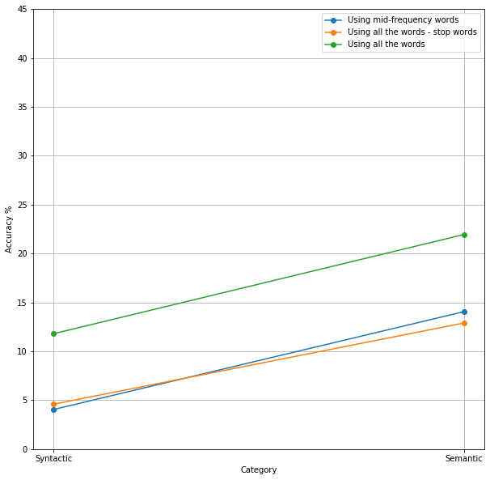

```python
plot_comparison(results)
```

#### Comparison of analogy solving accuracy percentages calculated using mid-frequency words embeddings obtained from:

#### - Using mid-frequency words

#### - Using all the words - stop words

#### - Using all the words

Here problems used for evaluation is same for all the cases. Each case is evaluated in all the problems whose words are present in mid-frequency words set.

```python
results = {'Using mid-frequency words' : {'Semantic': 14.05, 'Syntactic': 4.05},
           'Using all the words - stop words': {'Semantic': 16.01, 'Syntactic': 5.09},
           'Using all the words': {'Semantic': 19.28, 'Syntactic': 13.14}}
```

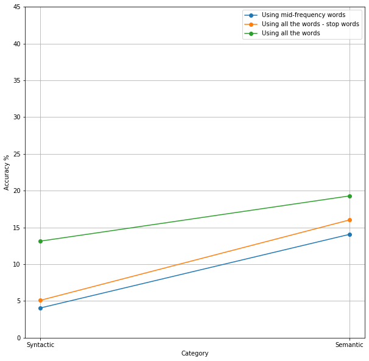

```python
plot_comparison(results)
```

#### Comparison of analogy solving accuracy percentages calculated using all words embeddings obtained from:

#### - Using all the words - stop words

#### - Expansion of mid-frequency embeddings to all the words (without stop words)

We are comparing these because they contain embeddings of same sets of words (mid-frequency words + rare words).

```python
results = {'Using all the words - stop words': {'Semantic': 12.89, 'Syntactic': 4.59},
           'Expansion using mid-frequency words embeddings': {'Semantic': 11.84, 'Syntactic': 3.62}}
```

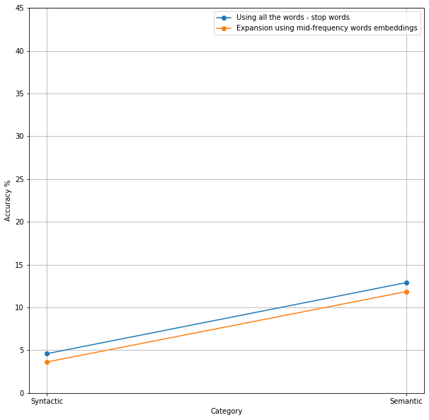

```python
plot_comparison(results)
```